Credit Approval Prediction

[figure not shown]

# Credit Approval Prediction (EDA, WOE & IV calculation, Modelling)

This is a classification model to determine whether a customer application for a credit card should be approved or rejected.

#### Context:

Credit score cards are a common risk control method in the financial industry. It uses personal information and data submitted by credit card applicants to predict the probability of future defaults and credit card borrowings. The bank is able to decide whether to issue a credit card to the applicant. Credit scores can objectively quantify the magnitude of risk.

Generally speaking, credit score cards are based on historical data. Once encountering large economic fluctuations. Past models may lose their original predictive power. Logistic model is a common method for credit scoring as it is suitable for binary classification tasks and can calculate the coefficients of each feature.

This credit card dataset consists of Application Record and Credit Record.

In this classification model, my plan is to:

- Observe the Weight of Evidence (WoE) and the Information Value (IV) of the features
- Use Synthetic Minority Oversampling Technique (SMOTE) to overcome class imbalance in the dataset
- Apply different algorithms to the training dataset:
  - Logistic Regression
  - Classification and Regression Tree (CART) or Decision Tree
  - Random Forest

```python
import pandas as pd
import numpy as np
import seaborn as sns
import matplotlib.pyplot as plt
import math

import warnings
warnings.filterwarnings("ignore")
```

### Application Record EDA

```python
appl_df = pd.read_csv('application_record.csv')
appl_df.head()
```

|  | ID | CODE_GENDER | FLAG_OWN_CAR | FLAG_OWN_REALTY | CNT_CHILDREN | AMT_INCOME_TOTAL | NAME_INCOME_TYPE | NAME_EDUCATION_TYPE | NAME_FAMILY_STATUS | NAME_HOUSING_TYPE | DAYS_BIRTH | DAYS_EMPLOYED | FLAG_MOBIL | FLAG_WORK_PHONE | FLAG_PHONE | FLAG_EMAIL | OCCUPATION_TYPE | CNT_FAM_MEMBERS |
| --- | --- | --- | --- | --- | --- | --- | --- | --- | --- | --- | --- | --- | --- | --- | --- | --- | --- | --- |
| 0 | 5008804 | M | Y | Y | 0 | 427500.0 | Working | Higher education | Civil marriage | Rented apartment | -12005 | -4542 | 1 | 1 | 0 | 0 | NaN | 2.0 |
| 1 | 5008805 | M | Y | Y | 0 | 427500.0 | Working | Higher education | Civil marriage | Rented apartment | -12005 | -4542 | 1 | 1 | 0 | 0 | NaN | 2.0 |
| 2 | 5008806 | M | Y | Y | 0 | 112500.0 | Working | Secondary / secondary special | Married | House / apartment | -21474 | -1134 | 1 | 0 | 0 | 0 | Security staff | 2.0 |
| 3 | 5008808 | F | N | Y | 0 | 270000.0 | Commercial associate | Secondary / secondary special | Single / not married | House / apartment | -19110 | -3051 | 1 | 0 | 1 | 1 | Sales staff | 1.0 |
| 4 | 5008809 | F | N | Y | 0 | 270000.0 | Commercial associate | Secondary / secondary special | Single / not married | House / apartment | -19110 | -3051 | 1 | 0 | 1 | 1 | Sales staff | 1.0 |

```python
appl_df.info()
```

```
<class 'pandas.core.frame.DataFrame'>
RangeIndex: 438557 entries, 0 to 438556
Data columns (total 18 columns):
 #   Column               Non-Null Count   Dtype
---  ------               --------------   -----
 0   ID                   438557 non-null  int64
 1   CODE_GENDER          438557 non-null  object
 2   FLAG_OWN_CAR         438557 non-null  object
 3   FLAG_OWN_REALTY      438557 non-null  object
 4   CNT_CHILDREN         438557 non-null  int64
 5   AMT_INCOME_TOTAL     438557 non-null  float64
 6   NAME_INCOME_TYPE     438557 non-null  object
 7   NAME_EDUCATION_TYPE  438557 non-null  object
 8   NAME_FAMILY_STATUS   438557 non-null  object
 9   NAME_HOUSING_TYPE    438557 non-null  object
 10  DAYS_BIRTH           438557 non-null  int64
 11  DAYS_EMPLOYED        438557 non-null  int64
 12  FLAG_MOBIL           438557 non-null  int64
 13  FLAG_WORK_PHONE      438557 non-null  int64
 14  FLAG_PHONE           438557 non-null  int64
 15  FLAG_EMAIL           438557 non-null  int64
 16  OCCUPATION_TYPE      304354 non-null  object
 17  CNT_FAM_MEMBERS      438557 non-null  float64
dtypes: float64(2), int64(8), object(8)
memory usage: 60.2+ MB
```

```python
# Check for duplicates
appl_df.duplicated().sum()
```

```
0
```

```python
# Check for null values
appl_df.isna().sum()/appl_df.shape[0]*100
```

```
ID                      0.000000
CODE_GENDER             0.000000
FLAG_OWN_CAR            0.000000
FLAG_OWN_REALTY         0.000000
CNT_CHILDREN            0.000000
AMT_INCOME_TOTAL        0.000000
NAME_INCOME_TYPE        0.000000
NAME_EDUCATION_TYPE     0.000000
NAME_FAMILY_STATUS      0.000000
NAME_HOUSING_TYPE       0.000000
DAYS_BIRTH              0.000000
DAYS_EMPLOYED           0.000000
FLAG_MOBIL              0.000000
FLAG_WORK_PHONE         0.000000
FLAG_PHONE              0.000000
FLAG_EMAIL              0.000000
OCCUPATION_TYPE        30.601039
CNT_FAM_MEMBERS         0.000000
dtype: float64
```

About 31% of occupation type is missing, which is significant.  
Let's try to look into the income type for this group.

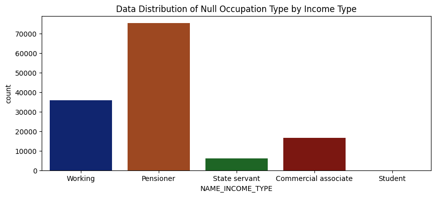

```python
plt.figure(figsize=(10,4))
sns.countplot(x=appl_df[appl_df["OCCUPATION_TYPE"].isna()]["NAME_INCOME_TYPE"], palette="dark")
plt.title("Data Distribution of Null Occupation Type by Income Type")
plt.show()
```

Most of the missing occupation type are pensioners, which make sense. Pensioners usually receive monthly pension payments.

It's okay for students to not have an occupation type.  
The others should be able to have occupation type, these null groups can be dropped from our dataset later.

```python
# label occupation type for pensioners and students
appl_df.loc[appl_df["NAME_INCOME_TYPE"]=="Pensioner", "OCCUPATION_TYPE"] = "Pensioner"
appl_df.loc[appl_df["NAME_INCOME_TYPE"]=="Student", "OCCUPATION_TYPE"] = "Student"
```

```python
# Explore Family Status
famstatus_val = appl_df.NAME_FAMILY_STATUS.value_counts(normalize = True)
famstatus_val
```

```
NAME_FAMILY_STATUS
Married                 0.683669
Single / not married    0.126029
Civil marriage          0.083300
Separated               0.062138
Widow                   0.044863
Name: proportion, dtype: float64
```

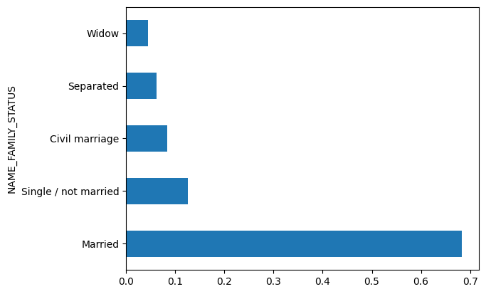

```python
famstatus_val.plot.barh()
plt.show()
```

```python
housing_val = appl_df.NAME_HOUSING_TYPE.value_counts(normalize = True)
housing_val
```

```
NAME_HOUSING_TYPE
House / apartment      0.898016
With parents           0.043499
Municipal apartment    0.032411
Rented apartment       0.013622
Office apartment       0.008943
Co-op apartment        0.003509
Name: proportion, dtype: float64
```

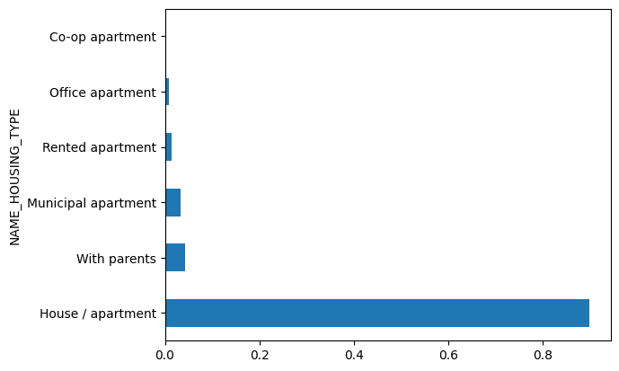

```python
housing_val.plot.barh()
plt.show()
```

*Application Record* consists of unique IDs and some details of the applicants.  
However, there is a lack of relevant financial data (e.g. Debt, Mortgage, Expenses) which can be very important for a credit card approval decision.

### Credit Record EDA

```python
credit_df = pd.read_csv('credit_record.csv')
credit_df.head()
```

|  | ID | MONTHS_BALANCE | STATUS |
| --- | --- | --- | --- |
| 0 | 5001711 | 0 | X |
| 1 | 5001711 | -1 | 0 |
| 2 | 5001711 | -2 | 0 |
| 3 | 5001711 | -3 | 0 |
| 4 | 5001712 | 0 | C |

The rows in *Credit Record* shows each month payment status for every unique IDs.

```python
credit_df.info()
```

```
<class 'pandas.core.frame.DataFrame'>
RangeIndex: 1048575 entries, 0 to 1048574
Data columns (total 3 columns):
 #   Column          Non-Null Count    Dtype
---  ------          --------------    -----
 0   ID              1048575 non-null  int64
 1   MONTHS_BALANCE  1048575 non-null  int64
 2   STATUS          1048575 non-null  object
dtypes: int64(2), object(1)
memory usage: 24.0+ MB
```

```python
# Check for duplicates
credit_df.duplicated().sum()
```

```
0
```

```python
# Check for null values
credit_df.isna().sum()/credit_df.shape[0]*100
```

```
ID                0.0
MONTHS_BALANCE    0.0
STATUS            0.0
dtype: float64
```

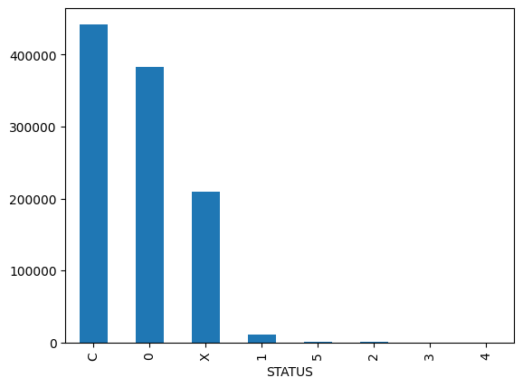

```python
credit_df.STATUS.value_counts().plot.bar()
plt.show()
```

X: No loan  
C: paid off that month (on time)  
0: 1-29 days past due  
1: 30-59 days past due  
2: 60-89 days past due  
3: 90-119 days past due  
4: 120-149 days past due  
5: 150+ days past due

The data only provides the credit record (status), but not the decision on whether we should approve a credit card, hence we need to set up the criteria for the payment behaviour we want to approve.

We consider customer who make at least 1 payment later than 30 days past due as high risk customer, and should not be approved.

### Identify Usable Samples

```python
print('For application record, number of unique customer ID is', appl_df['ID'].nunique())
print('For the credit record, number of unique customer ID is', credit_df['ID'].nunique())
print('Number of unique customer ID that appear in both records is:', appl_df[appl_df['ID'].isin(credit_df['ID'])]['ID'].nunique())
```

```
For application record, number of unique customer ID is 438510
For the credit record, number of unique customer ID is 45985
Number of unique customer ID that appear in both records is: 36457
```

We have **36457** unique IDs that are on both datasets. These are the samples that we can use to train our model.

```python
# Filter to get only usable samples
appl_df = appl_df[appl_df['ID'].isin(credit_df['ID'])]
credit_df = credit_df[credit_df['ID'].isin(appl_df['ID'])]
```

### Determine Approved and Denied Customers

```python
# Label the payments later than 30 days past due.
def highrisk(appl_df):
    if (appl_df["STATUS"]=='1') | (appl_df["STATUS"]=='2') | ( appl_df["STATUS"]=='3') | (appl_df["STATUS"]=='4') | (appl_df["STATUS"]=='5'): #high risk
        return 1
    else:
        return None
```

```python
# Create a series for High Risk in credit_df
credit_df["High Risk"] = credit_df.apply(highrisk, axis=1)
```

```python
# Group data by ID and count the occurences of high risk payments
count = credit_df.groupby('ID').count()
count.head()
```

| ID | MONTHS_BALANCE | STATUS | High Risk |
| --- | --- | --- | --- |
| 5008804 | 16 | 16 | 1 |
| 5008805 | 15 | 15 | 1 |
| 5008806 | 30 | 30 | 0 |
| 5008808 | 5 | 5 | 0 |
| 5008809 | 5 | 5 | 0 |

```python
# Label the customers that we want to approve
def determine_approval(count):
    if count["High Risk"] == 0:
        return 1
    else:
        return 0
```

```python
# Create a series for Approved in credit_df
count["Approved"] = count.apply(determine_approval, axis=1)
```

```python
count.head()
```

| ID | MONTHS_BALANCE | STATUS | High Risk | Approved |
| --- | --- | --- | --- | --- |
| 5008804 | 16 | 16 | 1 | 0 |
| 5008805 | 15 | 15 | 1 | 0 |
| 5008806 | 30 | 30 | 0 | 1 |
| 5008808 | 5 | 5 | 0 | 1 |
| 5008809 | 5 | 5 | 0 | 1 |

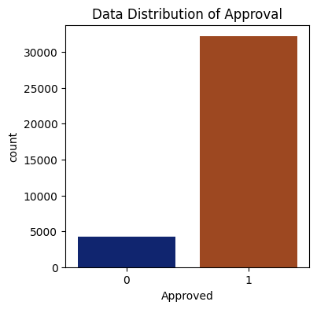

```python
# Check data distribution on our approval set
plt.figure(figsize=(4,4))
sns.countplot(x=count["Approved"], palette="dark")
plt.title("Data Distribution of Approval")
plt.show()
```

#### SMOTE and how it works

It is clear that samples are highly imbalanced and this will be an imbalanced classification. Hence, Synthetic Minority Oversampling Technique (SMOTE) is useful here.

SMOTE is a type of data augmentation for tabular data, it will synthesize new examples from the minority class, in this case, the declined set.

It works by selecting examples that are close in the feature space, drawing a line between the examples in the feature space and drawing a new sample at a point along that line.

A random example from the minority class is first chosen.  
Then k of the nearest neighbors for that example are found (typically k=5).  
A randomly selected neighbor is chosen and a synthetic example is created at a randomly selected point between the two examples in feature space.

### Merge Application Data & Approval Data

```python
# Merge application record with count dataframe
merged_df = pd.merge(appl_df, count, on='ID', how='inner')
merged_df.head()
```

|  | ID | CODE_GENDER | FLAG_OWN_CAR | FLAG_OWN_REALTY | CNT_CHILDREN | AMT_INCOME_TOTAL | NAME_INCOME_TYPE | NAME_EDUCATION_TYPE | NAME_FAMILY_STATUS | NAME_HOUSING_TYPE | ... | FLAG_MOBIL | FLAG_WORK_PHONE | FLAG_PHONE | FLAG_EMAIL | OCCUPATION_TYPE | CNT_FAM_MEMBERS | MONTHS_BALANCE | STATUS | High Risk | Approved |
| --- | --- | --- | --- | --- | --- | --- | --- | --- | --- | --- | --- | --- | --- | --- | --- | --- | --- | --- | --- | --- | --- |
| 0 | 5008804 | M | Y | Y | 0 | 427500.0 | Working | Higher education | Civil marriage | Rented apartment | ... | 1 | 1 | 0 | 0 | NaN | 2.0 | 16 | 16 | 1 | 0 |
| 1 | 5008805 | M | Y | Y | 0 | 427500.0 | Working | Higher education | Civil marriage | Rented apartment | ... | 1 | 1 | 0 | 0 | NaN | 2.0 | 15 | 15 | 1 | 0 |
| 2 | 5008806 | M | Y | Y | 0 | 112500.0 | Working | Secondary / secondary special | Married | House / apartment | ... | 1 | 0 | 0 | 0 | Security staff | 2.0 | 30 | 30 | 0 | 1 |
| 3 | 5008808 | F | N | Y | 0 | 270000.0 | Commercial associate | Secondary / secondary special | Single / not married | House / apartment | ... | 1 | 0 | 1 | 1 | Sales staff | 1.0 | 5 | 5 | 0 | 1 |
| 4 | 5008809 | F | N | Y | 0 | 270000.0 | Commercial associate | Secondary / secondary special | Single / not married | House / apartment | ... | 1 | 0 | 1 | 1 | Sales staff | 1.0 | 5 | 5 | 0 | 1 |

5 rows × 22 columns

```python
merged_df.info()
```

```
<class 'pandas.core.frame.DataFrame'>
RangeIndex: 36457 entries, 0 to 36456
Data columns (total 22 columns):
 #   Column               Non-Null Count  Dtype
---  ------               --------------  -----
 0   ID                   36457 non-null  int64
 1   CODE_GENDER          36457 non-null  object
 2   FLAG_OWN_CAR         36457 non-null  object
 3   FLAG_OWN_REALTY      36457 non-null  object
 4   CNT_CHILDREN         36457 non-null  int64
 5   AMT_INCOME_TOTAL     36457 non-null  float64
 6   NAME_INCOME_TYPE     36457 non-null  object
 7   NAME_EDUCATION_TYPE  36457 non-null  object
 8   NAME_FAMILY_STATUS   36457 non-null  object
 9   NAME_HOUSING_TYPE    36457 non-null  object
 10  DAYS_BIRTH           36457 non-null  int64
 11  DAYS_EMPLOYED        36457 non-null  int64
 12  FLAG_MOBIL           36457 non-null  int64
 13  FLAG_WORK_PHONE      36457 non-null  int64
 14  FLAG_PHONE           36457 non-null  int64
 15  FLAG_EMAIL           36457 non-null  int64
 16  OCCUPATION_TYPE      31274 non-null  object
 17  CNT_FAM_MEMBERS      36457 non-null  float64
 18  MONTHS_BALANCE       36457 non-null  int64
 19  STATUS               36457 non-null  int64
 20  High Risk            36457 non-null  int64
 21  Approved             36457 non-null  int64
dtypes: float64(2), int64(12), object(8)
memory usage: 6.1+ MB
```

```python
# Convert DAYS_BIRTH and DAYS_EMPLOYED into Age and Working Years
merged_df['AGE']=-(merged_df['DAYS_BIRTH'])//365
merged_df['WORKING_YEARS']=-(merged_df['DAYS_EMPLOYED'])//365
```

```python
merged_df.describe()
```

|  | ID | CNT_CHILDREN | AMT_INCOME_TOTAL | DAYS_BIRTH | DAYS_EMPLOYED | FLAG_MOBIL | FLAG_WORK_PHONE | FLAG_PHONE | FLAG_EMAIL | CNT_FAM_MEMBERS | MONTHS_BALANCE | STATUS | High Risk | Approved | AGE | WORKING_YEARS |
| --- | --- | --- | --- | --- | --- | --- | --- | --- | --- | --- | --- | --- | --- | --- | --- | --- |
| count | 3.645700e+04 | 36457.000000 | 3.645700e+04 | 36457.000000 | 36457.000000 | 36457.0 | 36457.000000 | 36457.000000 | 36457.000000 | 36457.000000 | 36457.000000 | 36457.000000 | 36457.000000 | 36457.000000 | 36457.000000 | 36457.000000 |
| mean | 5.078227e+06 | 0.430315 | 1.866857e+05 | -15975.173382 | 59262.935568 | 1.0 | 0.225526 | 0.294813 | 0.089722 | 2.198453 | 21.332392 | 21.332392 | 0.317497 | 0.882300 | 43.260334 | -162.834161 |
| std | 4.187524e+04 | 0.742367 | 1.017892e+05 | 4200.549944 | 137651.334859 | 0.0 | 0.417934 | 0.455965 | 0.285787 | 0.911686 | 14.911849 | 14.911849 | 1.531811 | 0.322257 | 11.510414 | 377.066049 |
| min | 5.008804e+06 | 0.000000 | 2.700000e+04 | -25152.000000 | -15713.000000 | 1.0 | 0.000000 | 0.000000 | 0.000000 | 1.000000 | 1.000000 | 1.000000 | 0.000000 | 0.000000 | 20.000000 | -1001.000000 |
| 25% | 5.042028e+06 | 0.000000 | 1.215000e+05 | -19438.000000 | -3153.000000 | 1.0 | 0.000000 | 0.000000 | 0.000000 | 2.000000 | 9.000000 | 9.000000 | 0.000000 | 1.000000 | 34.000000 | 1.000000 |
| 50% | 5.074614e+06 | 0.000000 | 1.575000e+05 | -15563.000000 | -1552.000000 | 1.0 | 0.000000 | 0.000000 | 0.000000 | 2.000000 | 18.000000 | 18.000000 | 0.000000 | 1.000000 | 42.000000 | 4.000000 |
| 75% | 5.115396e+06 | 1.000000 | 2.250000e+05 | -12462.000000 | -408.000000 | 1.0 | 0.000000 | 1.000000 | 0.000000 | 3.000000 | 31.000000 | 31.000000 | 0.000000 | 1.000000 | 53.000000 | 8.000000 |
| max | 5.150487e+06 | 19.000000 | 1.575000e+06 | -7489.000000 | 365243.000000 | 1.0 | 1.000000 | 1.000000 | 1.000000 | 20.000000 | 61.000000 | 61.000000 | 49.000000 | 1.000000 | 68.000000 | 43.000000 |

FLAG_MOBIL has 0 standard deviation hence it adds no value to the model. This column can be dropped.

```python
# Drop FLAG_MOBIL
merged_df = merged_df.drop('FLAG_MOBIL', axis=1)
```

```python
# Check for customers with negative WORKING_YEARS
merged_df[merged_df['WORKING_YEARS'] < 0]
```

|  | ID | CODE_GENDER | FLAG_OWN_CAR | FLAG_OWN_REALTY | CNT_CHILDREN | AMT_INCOME_TOTAL | NAME_INCOME_TYPE | NAME_EDUCATION_TYPE | NAME_FAMILY_STATUS | NAME_HOUSING_TYPE | ... | FLAG_PHONE | FLAG_EMAIL | OCCUPATION_TYPE | CNT_FAM_MEMBERS | MONTHS_BALANCE | STATUS | High Risk | Approved | AGE | WORKING_YEARS |
| --- | --- | --- | --- | --- | --- | --- | --- | --- | --- | --- | --- | --- | --- | --- | --- | --- | --- | --- | --- | --- | --- |
| 7 | 5008812 | F | N | Y | 0 | 283500.0 | Pensioner | Higher education | Separated | House / apartment | ... | 0 | 0 | Pensioner | 1.0 | 17 | 17 | 0 | 1 | 61 | -1001 |
| 8 | 5008813 | F | N | Y | 0 | 283500.0 | Pensioner | Higher education | Separated | House / apartment | ... | 0 | 0 | Pensioner | 1.0 | 17 | 17 | 0 | 1 | 61 | -1001 |
| 9 | 5008814 | F | N | Y | 0 | 283500.0 | Pensioner | Higher education | Separated | House / apartment | ... | 0 | 0 | Pensioner | 1.0 | 17 | 17 | 0 | 1 | 61 | -1001 |
| 69 | 5008884 | F | N | Y | 0 | 315000.0 | Pensioner | Secondary / secondary special | Widow | House / apartment | ... | 0 | 0 | Pensioner | 1.0 | 41 | 41 | 0 | 1 | 55 | -1001 |
| 150 | 5008974 | F | N | Y | 0 | 112500.0 | Pensioner | Secondary / secondary special | Married | House / apartment | ... | 0 | 0 | Pensioner | 2.0 | 3 | 3 | 0 | 1 | 61 | -1001 |
| ... | ... | ... | ... | ... | ... | ... | ... | ... | ... | ... | ... | ... | ... | ... | ... | ... | ... | ... | ... | ... | ... |
| 36408 | 5126278 | F | N | N | 0 | 162000.0 | Pensioner | Secondary / secondary special | Married | House / apartment | ... | 0 | 0 | Pensioner | 2.0 | 29 | 29 | 9 | 0 | 58 | -1001 |
| 36418 | 5139446 | F | N | Y | 0 | 112500.0 | Pensioner | Secondary / secondary special | Widow | House / apartment | ... | 1 | 0 | Pensioner | 1.0 | 17 | 17 | 4 | 0 | 58 | -1001 |
| 36432 | 5145690 | F | N | Y | 0 | 306000.0 | Pensioner | Higher education | Married | House / apartment | ... | 0 | 0 | Pensioner | 2.0 | 18 | 18 | 13 | 0 | 59 | -1001 |
| 36434 | 5145817 | F | N | Y | 0 | 90000.0 | Pensioner | Secondary / secondary special | Married | House / apartment | ... | 0 | 0 | Pensioner | 2.0 | 40 | 40 | 1 | 0 | 60 | -1001 |
| 36439 | 5148602 | M | N | Y | 0 | 225000.0 | Pensioner | Secondary / secondary special | Married | House / apartment | ... | 0 | 0 | Pensioner | 2.0 | 16 | 16 | 2 | 0 | 62 | -1001 |

6135 rows × 23 columns

customers with negative WORKING_YEARS are pensioners and represent a valid data

```python
# Replace WORKING_YEARS for all pensioners to be -1
merged_df.loc[merged_df["NAME_INCOME_TYPE"]=="Pensioner", "WORKING_YEARS"] = -1
```

```python
# Drop rows with null values
merged_df = merged_df.dropna(axis=0)
```

```python
# Drop columns we no longer use
merged_df = merged_df.drop('ID', axis=1)
merged_df = merged_df.drop('MONTHS_BALANCE', axis=1)
merged_df = merged_df.drop('STATUS', axis=1)
merged_df = merged_df.drop('High Risk', axis=1)
merged_df = merged_df.drop('DAYS_BIRTH', axis=1)
merged_df = merged_df.drop('DAYS_EMPLOYED', axis=1)
```

```python
# Drop CODE_GENDER to prevent gender discrimination in the model
merged_df = merged_df.drop('CODE_GENDER', axis=1)
```

### Approved Customers EDA

##### Distribution of Annual Income ('000)

```
AMT_INCOME_TOTAL
(25.451, 181.8]     19356
(181.8, 336.6]       9751
(336.6, 491.4]       1769
(491.4, 646.2]        193
(646.2, 801.0]        134
(801.0, 955.8]         50
(955.8, 1110.6]         4
(1110.6, 1265.4]        3
(1265.4, 1420.2]        6
(1420.2, 1575.0]        8
Name: count, dtype: int64
```

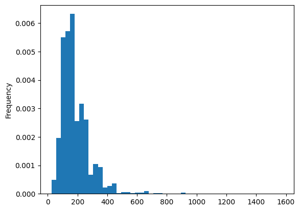

```python
merged_df['AMT_INCOME_TOTAL']=merged_df['AMT_INCOME_TOTAL'].astype(object)
merged_df['AMT_INCOME_TOTAL'] = merged_df['AMT_INCOME_TOTAL']/1000
print(merged_df['AMT_INCOME_TOTAL'].value_counts(bins=10,sort=False))
merged_df['AMT_INCOME_TOTAL'].plot(kind='hist',bins=50,density=True)
```

##### Distribution of Age

```
AGE
(19.951, 24.8]    0.020304
(24.8, 29.6]      0.108557
(29.6, 34.4]      0.136887
(34.4, 39.2]      0.142451
(39.2, 44.0]      0.137878
(44.0, 48.8]      0.091833
(48.8, 53.6]      0.107469
(53.6, 58.4]      0.111882
(58.4, 63.2]      0.101746
(63.2, 68.0]      0.040993
Name: proportion, dtype: float64
```

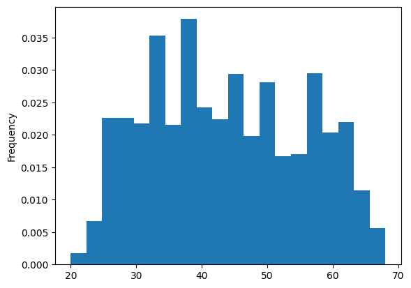

```python
print(merged_df['AGE'].value_counts(bins=10,normalize=True,sort=False))
merged_df['AGE'].plot(kind='hist',bins=20,density=True)
```

##### Distribution of Working Years

```
WORKING_YEARS
(-1.045, 3.4]    15680
(3.4, 7.8]        7206
(7.8, 12.2]       4667
(12.2, 16.6]      1617
(16.6, 21.0]      1064
(21.0, 25.4]       525
(25.4, 29.8]       274
(29.8, 34.2]       151
(34.2, 38.6]        58
(38.6, 43.0]        32
Name: count, dtype: int64
```

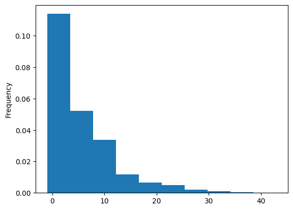

```python
print(merged_df['WORKING_YEARS'].value_counts(bins=10,sort=False))
merged_df['WORKING_YEARS'].plot(kind='hist',bins=10,density=True)
```

##### Approval Count Heatmap

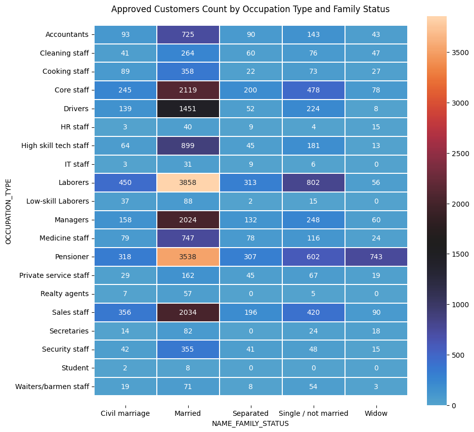

```python
pvt_tbl = pd.pivot_table(data = merged_df,
                         index = ['OCCUPATION_TYPE'],
                         columns = ['NAME_FAMILY_STATUS'],
                         values = 'Approved',
                         aggfunc = sum,  fill_value = 0)

plt.figure(figsize=[10,10])
hm = sns.heatmap(data = pvt_tbl,
                 annot = True,
                 fmt='.0f',
                 linewidths=.2,
                 center = 1600)

bottom, top = hm.get_ylim()
hm.set_ylim(bottom + 0.5, top - 0.5)
plt.title("Approved Customers Count by Occupation Type and Family Status")
plt.show()
```

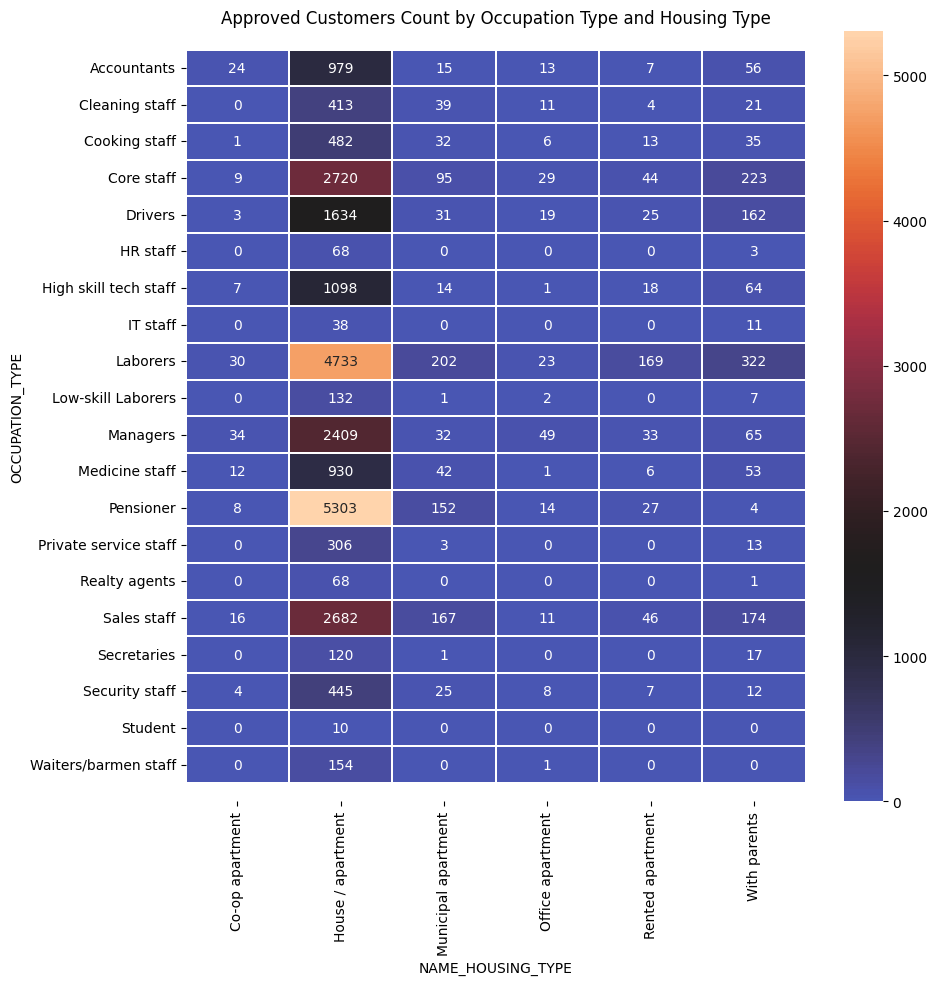

```python
pvt_tbl = pd.pivot_table(data = merged_df,
                         index = ['OCCUPATION_TYPE'],
                         columns = ['NAME_HOUSING_TYPE'],
                         values = 'Approved',
                         aggfunc = sum,  fill_value = 0)

plt.figure(figsize=[10,10])
hm = sns.heatmap(data = pvt_tbl,
                 annot = True,
                 fmt='.0f',
                 linewidths=.2,
                 center = 1600)

bottom, top = hm.get_ylim()
hm.set_ylim(bottom + 0.5, top - 0.5)
plt.title("Approved Customers Count by Occupation Type and Housing Type")
plt.show()
```

### Calculate WOE and IV

Weight of Evidence(WOE):

$$Wo{E_i} = \ln {{{P_{yi}}} \over {{P_{ni}}}} = \ln {{{y_i}/{y_s}} \over {{n_i}/{n_s}}}$$

$Wo{E_i}$ is the WOE value for category ${i}$.  
${{P_{yi}}}$ is the proportion of the positive samples in category ${i}$ (${{y_i}}$) to all positive samples (${{y_s}}$).  
${{P_{ni}}}$ is the proportion of negative samples in category ${i}$ (${{n_i}}$) to all negative samples (${{n_s}}$).

Information Value (IV):
$$I{V_i} = Wo{E_i} \times ({P_{yi}} - {P_{ni}})$$ $$IV = \sum\limits_i^n {I{V_i}} $$ The IVs of a category are the WOE value of the category multiplied by the difference between the conditional positive rate and the conditional negative rate.
The total IV of the variable can be understood as the weighted sum of the conditional positive rate and the conditional negative rate difference.

IV is an excellent feature selection method for a binary logistic regression classification model as conditional log odds that are predicted in the model is highly related to the Weight of Evidence (WOE).

Relationship between IV and the variable's predictive power

| IV | Ability to predict |
| --- | --- |
| <0.02 | Almost no predictive power |
| 0.02~0.1 | weak predictive power |
| 0.1~0.3 | Moderate predictive power |
| 0.3~0.5 | Strong predictive power |
| >0.5 | Predictive power is too strong, need to check variables |

```python
def calc_woe_iv(feature) :
    df = pd.DataFrame(columns = ['values','total','good','bad','good_rate','bad_rate','dist_good','dist_bad','WOE','IV'])
    df['values'] = merged_df[feature].unique()
    df.set_index('values', inplace = True)

    values = merged_df[feature].unique()
    total_dict = dict(merged_df.groupby(feature).size())
    col_approved_dict = dict(merged_df.groupby([feature,'Approved']).size())
    approved_count = dict(merged_df.groupby(['Approved']).size())

    for value in values :
        df.loc[value]['total'] = total_dict[value]
        if (value,1) in col_approved_dict:
            df.loc[value]['good'] = col_approved_dict[(value,1)]
        else :
            df.loc[value]['good'] = 0

        if (value,0) in col_approved_dict:
            df.loc[value]['bad'] = col_approved_dict[(value,0)]
        else :
            df.loc[value]['bad'] = 0

        if df.loc[value]['bad'] == 0 :
            df = df.drop([value])

    df['good_rate'] = df['good']/df['total']
    df['bad_rate'] = df['bad']/df['total']

    df['dist_good'] = df['good']/approved_count[1]
    df['dist_bad'] = df['bad']/approved_count[0]

    df['WOE'] = np.log(df.dist_good.astype('float64')/df.dist_bad.astype('float64'))
    df['IV'] = df['WOE'] * (df['dist_good'] - df['dist_bad'])


    iv = df['IV'].sum()
    print("Information value (IV):", iv)
    return df
```

```python
iv_table = pd.DataFrame(columns = ['feature','iv'])
```

```python
iv_table['feature'] = merged_df.columns
iv_table.set_index(['feature'],inplace = True)
iv_table.drop(['Approved'],inplace = True)
iv_table
```

| feature | iv |
| --- | --- |
| FLAG_OWN_CAR | NaN |
| FLAG_OWN_REALTY | NaN |
| CNT_CHILDREN | NaN |
| AMT_INCOME_TOTAL | NaN |
| NAME_INCOME_TYPE | NaN |
| NAME_EDUCATION_TYPE | NaN |
| NAME_FAMILY_STATUS | NaN |
| NAME_HOUSING_TYPE | NaN |
| FLAG_WORK_PHONE | NaN |
| FLAG_PHONE | NaN |
| FLAG_EMAIL | NaN |
| OCCUPATION_TYPE | NaN |
| CNT_FAM_MEMBERS | NaN |
| AGE | NaN |
| WORKING_YEARS | NaN |

### Binary Variables

##### Possession of Car

```python
merged_df['FLAG_OWN_CAR'] = merged_df['FLAG_OWN_CAR'].replace(['N','Y'], [0,1])
FLAG_OWN_CAR_df = calc_woe_iv('FLAG_OWN_CAR')
iv_table.loc['FLAG_OWN_CAR'] = FLAG_OWN_CAR_df.IV.sum()
FLAG_OWN_CAR_df
```

```
Information value (IV): 0.00047516760905406334
```

| values | total | good | bad | good_rate | bad_rate | dist_good | dist_bad | WOE | IV |
| --- | --- | --- | --- | --- | --- | --- | --- | --- | --- |
| 1 | 11805 | 10435 | 1370 | 0.883947 | 0.116053 | 0.378725 | 0.368181 | 0.028236 | 0.000298 |
| 0 | 19469 | 17118 | 2351 | 0.879244 | 0.120756 | 0.621275 | 0.631819 | -0.016829 | 0.000177 |

##### Possession of Realty Property

```python
merged_df['FLAG_OWN_REALTY'] = merged_df['FLAG_OWN_REALTY'].replace(['N','Y'], [0,1])
FLAG_OWN_REALTY_df = calc_woe_iv('FLAG_OWN_REALTY')
iv_table.loc['FLAG_OWN_REALTY'] = FLAG_OWN_REALTY_df.IV.sum()
FLAG_OWN_REALTY_df
```

```
Information value (IV): 0.010526936966177698
```

| values | total | good | bad | good_rate | bad_rate | dist_good | dist_bad | WOE | IV |
| --- | --- | --- | --- | --- | --- | --- | --- | --- | --- |
| 1 | 21183 | 18822 | 2361 | 0.888543 | 0.111457 | 0.68312 | 0.634507 | 0.073822 | 0.003589 |
| 0 | 10091 | 8731 | 1360 | 0.865226 | 0.134774 | 0.31688 | 0.365493 | -0.142724 | 0.006938 |

##### Possession of Phone

```python
FLAG_PHONE_df = calc_woe_iv('FLAG_PHONE')
iv_table.loc['FLAG_PHONE'] = FLAG_PHONE_df.IV.sum()
FLAG_PHONE_df
```

```
Information value (IV): 0.0017100207770481316
```

| values | total | good | bad | good_rate | bad_rate | dist_good | dist_bad | WOE | IV |
| --- | --- | --- | --- | --- | --- | --- | --- | --- | --- |
| 0 | 22145 | 19449 | 2696 | 0.878257 | 0.121743 | 0.705876 | 0.724536 | -0.026093 | 0.000487 |
| 1 | 9129 | 8104 | 1025 | 0.88772 | 0.11228 | 0.294124 | 0.275464 | 0.065546 | 0.001223 |

##### Possession of Work Phone

```python
FLAG_WORK_PHONE_df = calc_woe_iv('FLAG_WORK_PHONE')
iv_table.loc['FLAG_WORK_PHONE'] = FLAG_WORK_PHONE_df.IV.sum()
FLAG_WORK_PHONE_df
```

```
Information value (IV): 4.3508959059651395e-05
```

| values | total | good | bad | good_rate | bad_rate | dist_good | dist_bad | WOE | IV |
| --- | --- | --- | --- | --- | --- | --- | --- | --- | --- |
| 0 | 24391 | 21480 | 2911 | 0.880653 | 0.119347 | 0.779588 | 0.782317 | -0.003493 | 0.00001 |
| 1 | 6883 | 6073 | 810 | 0.882319 | 0.117681 | 0.220412 | 0.217683 | 0.012455 | 0.000034 |

##### Possession of Email

```python
FLAG_EMAIL_df = calc_woe_iv('FLAG_EMAIL')
iv_table.loc['FLAG_EMAIL'] = FLAG_EMAIL_df.IV.sum()
FLAG_EMAIL_df
```

```
Information value (IV): 0.003934518023302461
```

| values | total | good | bad | good_rate | bad_rate | dist_good | dist_bad | WOE | IV |
| --- | --- | --- | --- | --- | --- | --- | --- | --- | --- |
| 0 | 28527 | 25193 | 3334 | 0.883128 | 0.116872 | 0.914347 | 0.895996 | 0.020274 | 0.000372 |
| 1 | 2747 | 2360 | 387 | 0.859119 | 0.140881 | 0.085653 | 0.104004 | -0.194127 | 0.003562 |

### Continuous Variables

##### Number of Children

```python
merged_df['cnt_child_bin'] = merged_df.CNT_CHILDREN.apply(lambda x : '2+' if x>= 2 else str(x))
```

```python
CNT_CHILDREN_df = calc_woe_iv('cnt_child_bin')
iv_table.loc['CNT_CHILDREN'] = CNT_CHILDREN_df.IV.sum()
CNT_CHILDREN_df
```

```
Information value (IV): 0.0005624845340762583
```

| values | total | good | bad | good_rate | bad_rate | dist_good | dist_bad | WOE | IV |
| --- | --- | --- | --- | --- | --- | --- | --- | --- | --- |
| 0 | 21819 | 19222 | 2597 | 0.880975 | 0.119025 | 0.697637 | 0.697931 | -0.000420 | 0.0 |
| 2+ | 3169 | 2772 | 397 | 0.874724 | 0.125276 | 0.100606 | 0.106692 | -0.058731 | 0.000357 |
| 1 | 6286 | 5559 | 727 | 0.884346 | 0.115654 | 0.201757 | 0.195378 | 0.032128 | 0.000205 |

##### Annual Income

```python
bins = [0, 70, 100, 150, 200, 250, 300, 350, 1600]
labels = ['70', '100', '150', '200', '250', '300', '350', '1600']
merged_df['income_bin'] = pd.cut(merged_df['AMT_INCOME_TOTAL'], bins = bins, labels = labels)
```

```python
merged_df.income_bin.value_counts()
```

```
income_bin
150     8830
200     6564
250     5865
100     3004
300     2416
1600    1936
70      1395
350     1264
Name: count, dtype: int64
```

```python
AMT_INCOME_TOTAL_df = calc_woe_iv('income_bin')
iv_table.loc['AMT_INCOME_TOTAL'] = AMT_INCOME_TOTAL_df.IV.sum()
AMT_INCOME_TOTAL_df.sort_values(by = 'WOE', inplace = True)
AMT_INCOME_TOTAL_df
```

```
Information value (IV): 0.014692899629109128
```

| values | total | good | bad | good_rate | bad_rate | dist_good | dist_bad | WOE | IV |
| --- | --- | --- | --- | --- | --- | --- | --- | --- | --- |
| 250 | 5865 | 5047 | 818 | 0.860529 | 0.139471 | 0.183174 | 0.219833 | -0.182432 | 0.006688 |
| 350 | 1264 | 1098 | 166 | 0.868671 | 0.131329 | 0.03985 | 0.044612 | -0.112861 | 0.000537 |
| 1600 | 1936 | 1689 | 247 | 0.872417 | 0.127583 | 0.0613 | 0.06638 | -0.079615 | 0.000404 |
| 300 | 2416 | 2117 | 299 | 0.876242 | 0.123758 | 0.076834 | 0.080355 | -0.044807 | 0.000158 |
| 100 | 3004 | 2647 | 357 | 0.881158 | 0.118842 | 0.096069 | 0.095942 | 0.001327 | 0.0 |
| 150 | 8830 | 7816 | 1014 | 0.885164 | 0.114836 | 0.283671 | 0.272507 | 0.040151 | 0.000448 |
| 200 | 6564 | 5880 | 684 | 0.895795 | 0.104205 | 0.213407 | 0.183822 | 0.149235 | 0.004415 |
| 70 | 1395 | 1259 | 136 | 0.902509 | 0.097491 | 0.045694 | 0.036549 | 0.223299 | 0.002042 |

##### Number of Family Members

```python
merged_df.CNT_FAM_MEMBERS.value_counts()
```

```
CNT_FAM_MEMBERS
2.0     16774
1.0      6100
3.0      5383
4.0      2625
5.0       317
6.0        51
7.0        18
15.0        3
9.0         2
20.0        1
Name: count, dtype: int64
```

```python
merged_df['cnt_family_bin'] = merged_df.CNT_FAM_MEMBERS.apply(lambda x : '4+' if x>= 4 else str(x))
```

```python
CNT_FAM_MEMBERS_df = calc_woe_iv('cnt_family_bin')
iv_table.loc['CNT_FAM_MEMBERS'] = CNT_FAM_MEMBERS_df.IV.sum()
CNT_FAM_MEMBERS_df.sort_values(by = 'WOE', inplace = True)
CNT_FAM_MEMBERS_df
```

```
Information value (IV): 0.001482738217308712
```

| values | total | good | bad | good_rate | bad_rate | dist_good | dist_bad | WOE | IV |
| --- | --- | --- | --- | --- | --- | --- | --- | --- | --- |
| 4+ | 3017 | 2629 | 388 | 0.871395 | 0.128605 | 0.095416 | 0.104273 | -0.088765 | 0.000786 |
| 1.0 | 6100 | 5353 | 747 | 0.877541 | 0.122459 | 0.19428 | 0.200752 | -0.032772 | 0.000212 |
| 2.0 | 16774 | 14802 | 1972 | 0.882437 | 0.117563 | 0.537219 | 0.529965 | 0.013595 | 0.000099 |
| 3.0 | 5383 | 4769 | 614 | 0.885937 | 0.114063 | 0.173085 | 0.165009 | 0.047778 | 0.000386 |

##### Age

```python
bins = [19, 27, 30, 35, 40, 45, 50, 55, 62, 70]
labels = ['27','30','35','40','45','50','55','62','70']
merged_df['age_bin'] = pd.cut(merged_df['AGE'], bins = bins, labels = labels)
merged_df.age_bin.value_counts()
```

```
age_bin
62    4871
40    4590
35    4246
45    4004
50    3566
55    3302
30    2552
27    2332
70    1811
Name: count, dtype: int64
```

```python
AGE_df = calc_woe_iv('age_bin')
iv_table.loc['AGE'] = AGE_df.IV.sum()
AGE_df.sort_values(by = 'WOE', inplace = True)
AGE_df
```

```
Information value (IV): 0.01428216840831179
```

| values | total | good | bad | good_rate | bad_rate | dist_good | dist_bad | WOE | IV |
| --- | --- | --- | --- | --- | --- | --- | --- | --- | --- |
| 27 | 2332 | 2004 | 328 | 0.859348 | 0.140652 | 0.072733 | 0.088148 | -0.192232 | 0.002963 |
| 30 | 2552 | 2198 | 354 | 0.861285 | 0.138715 | 0.079774 | 0.095136 | -0.176113 | 0.002705 |
| 35 | 4246 | 3677 | 569 | 0.865992 | 0.134008 | 0.133452 | 0.152916 | -0.136147 | 0.00265 |
| 55 | 3302 | 2907 | 395 | 0.880376 | 0.119624 | 0.105506 | 0.106154 | -0.006128 | 0.000004 |
| 50 | 3566 | 3149 | 417 | 0.883062 | 0.116938 | 0.114289 | 0.112067 | 0.019635 | 0.000044 |
| 45 | 4004 | 3550 | 454 | 0.886613 | 0.113387 | 0.128843 | 0.12201 | 0.054487 | 0.000372 |
| 62 | 4871 | 4338 | 533 | 0.890577 | 0.109423 | 0.157442 | 0.143241 | 0.094528 | 0.001342 |
| 40 | 4590 | 4099 | 491 | 0.893028 | 0.106972 | 0.148768 | 0.131954 | 0.119935 | 0.002017 |
| 70 | 1811 | 1631 | 180 | 0.900607 | 0.099393 | 0.059195 | 0.048374 | 0.201873 | 0.002184 |

##### Working Years

```python
bins = [-2, -1,  5, 10, 15,  20, 50]
labels = ['retired','5','10','15','20','20+']
merged_df['wkg_years_bin'] = pd.cut(merged_df['WORKING_YEARS'], bins = bins, labels = labels)
merged_df.wkg_years_bin.value_counts()
```

```
wkg_years_bin
5          13694
10          6515
retired     6152
15          2600
20+         1179
20          1134
Name: count, dtype: int64
```

```python
WORKING_YEARS_df = calc_woe_iv('wkg_years_bin')
iv_table.loc['WORKING_YEARS'] = WORKING_YEARS_df.IV.sum()
WORKING_YEARS_df.sort_values(by = 'WOE',inplace = True)
WORKING_YEARS_df
```

```
Information value (IV): 0.007172907442583332
```

| values | total | good | bad | good_rate | bad_rate | dist_good | dist_bad | WOE | IV |
| --- | --- | --- | --- | --- | --- | --- | --- | --- | --- |
| 15 | 2600 | 2268 | 332 | 0.872308 | 0.127692 | 0.082314 | 0.089223 | -0.080600 | 0.000557 |
| 20 | 1134 | 991 | 143 | 0.873898 | 0.126102 | 0.035967 | 0.038431 | -0.066249 | 0.000163 |
| 5 | 13694 | 11978 | 1716 | 0.87469 | 0.12531 | 0.434726 | 0.461166 | -0.059043 | 0.001561 |
| 10 | 6515 | 5750 | 765 | 0.882579 | 0.117421 | 0.208689 | 0.20559 | 0.014960 | 0.000046 |
| retired | 6152 | 5508 | 644 | 0.895319 | 0.104681 | 0.199906 | 0.173072 | 0.144139 | 0.003868 |
| 20+ | 1179 | 1058 | 121 | 0.897371 | 0.102629 | 0.038399 | 0.032518 | 0.166226 | 0.000978 |

### Categorical Variables

##### Income Type

```python
NAME_INCOME_TYPE_df = calc_woe_iv('NAME_INCOME_TYPE')
iv_table.loc['NAME_INCOME_TYPE'] = NAME_INCOME_TYPE_df.IV.sum()
NAME_INCOME_TYPE_df
```

```
Information value (IV): 0.006580480165306965
```

| values | total | good | bad | good_rate | bad_rate | dist_good | dist_bad | WOE | IV |
| --- | --- | --- | --- | --- | --- | --- | --- | --- | --- |
| Working | 15622 | 13770 | 1852 | 0.881449 | 0.118551 | 0.499764 | 0.497716 | 0.004107 | 0.000008 |
| Commercial associate | 7052 | 6144 | 908 | 0.871242 | 0.128758 | 0.222988 | 0.24402 | -0.090132 | 0.001896 |
| Pensioner | 6152 | 5508 | 644 | 0.895319 | 0.104681 | 0.199906 | 0.173072 | 0.144139 | 0.003868 |
| State servant | 2437 | 2121 | 316 | 0.870332 | 0.129668 | 0.076979 | 0.084923 | -0.098218 | 0.00078 |
| Student | 11 | 10 | 1 | 0.909091 | 0.090909 | 0.000363 | 0.000269 | 0.300466 | 0.000028 |

##### Education Level

```python
NAME_EDUCATION_TYPE_df = calc_woe_iv('NAME_EDUCATION_TYPE')
iv_table.loc['NAME_EDUCATION_TYPE'] = NAME_EDUCATION_TYPE_df.IV.sum()
NAME_EDUCATION_TYPE_df
```

```
Information value (IV): 0.003972847939147731
```

| values | total | good | bad | good_rate | bad_rate | dist_good | dist_bad | WOE | IV |
| --- | --- | --- | --- | --- | --- | --- | --- | --- | --- |
| Secondary / secondary special | 21720 | 19144 | 2576 | 0.8814 | 0.1186 | 0.694806 | 0.692287 | 0.003633 | 0.000009 |
| Higher education | 8141 | 7182 | 959 | 0.882201 | 0.117799 | 0.260661 | 0.257726 | 0.011323 | 0.000033 |
| Incomplete higher | 1051 | 904 | 147 | 0.860133 | 0.139867 | 0.032809 | 0.039506 | -0.185722 | 0.001244 |
| Lower secondary | 347 | 314 | 33 | 0.904899 | 0.095101 | 0.011396 | 0.008869 | 0.250766 | 0.000634 |
| Academic degree | 15 | 9 | 6 | 0.6 | 0.4 | 0.000327 | 0.001612 | -1.596654 | 0.002053 |

##### Family Status

```python
NAME_FAMILY_STATUS_df = calc_woe_iv('NAME_FAMILY_STATUS')
iv_table.loc['NAME_FAMILY_STATUS'] = NAME_FAMILY_STATUS_df.IV.sum()
NAME_FAMILY_STATUS_df
```

```
Information value (IV): 0.003208161449406242
```

| values | total | good | bad | good_rate | bad_rate | dist_good | dist_bad | WOE | IV |
| --- | --- | --- | --- | --- | --- | --- | --- | --- | --- |
| Married | 21424 | 18911 | 2513 | 0.882702 | 0.117298 | 0.68635 | 0.675356 | 0.016148 | 0.000178 |
| Single / not married | 4127 | 3586 | 541 | 0.868912 | 0.131088 | 0.130149 | 0.145391 | -0.110746 | 0.001688 |
| Separated | 1812 | 1609 | 203 | 0.887969 | 0.112031 | 0.058397 | 0.054555 | 0.068043 | 0.000261 |
| Civil marriage | 2503 | 2188 | 315 | 0.874151 | 0.125849 | 0.079411 | 0.084655 | -0.063948 | 0.000335 |
| Widow | 1408 | 1259 | 149 | 0.894176 | 0.105824 | 0.045694 | 0.040043 | 0.132008 | 0.000746 |

##### Housing Type

```python
NAME_HOUSING_TYPE_df = calc_woe_iv('NAME_HOUSING_TYPE')
iv_table.loc['NAME_HOUSING_TYPE'] = NAME_HOUSING_TYPE_df.IV.sum()
NAME_HOUSING_TYPE_df
```

```
Information value (IV): 0.005002140385334694
```

| values | total | good | bad | good_rate | bad_rate | dist_good | dist_bad | WOE | IV |
| --- | --- | --- | --- | --- | --- | --- | --- | --- | --- |
| House / apartment | 28000 | 24724 | 3276 | 0.883 | 0.117 | 0.897325 | 0.880408 | 0.019032 | 0.000322 |
| Rented apartment | 469 | 399 | 70 | 0.850746 | 0.149254 | 0.014481 | 0.018812 | -0.261653 | 0.001133 |
| Municipal apartment | 989 | 851 | 138 | 0.860465 | 0.139535 | 0.030886 | 0.037087 | -0.182961 | 0.001135 |
| With parents | 1437 | 1243 | 194 | 0.864997 | 0.135003 | 0.045113 | 0.052137 | -0.144694 | 0.001016 |
| Co-op apartment | 160 | 148 | 12 | 0.925 | 0.075 | 0.005371 | 0.003225 | 0.510187 | 0.001095 |
| Office apartment | 219 | 188 | 31 | 0.858447 | 0.141553 | 0.006823 | 0.008331 | -0.199664 | 0.000301 |

##### Occupation Type

```python
OCCUPATION_TYPE_df = calc_woe_iv('OCCUPATION_TYPE')
iv_table.loc['OCCUPATION_TYPE'] = OCCUPATION_TYPE_df.IV.sum()
OCCUPATION_TYPE_df
```

```
Information value (IV): 0.017190146841521217
```

| values | total | good | bad | good_rate | bad_rate | dist_good | dist_bad | WOE | IV |
| --- | --- | --- | --- | --- | --- | --- | --- | --- | --- |
| Security staff | 592 | 501 | 91 | 0.846284 | 0.153716 | 0.018183 | 0.024456 | -0.296372 | 0.001859 |
| Sales staff | 3485 | 3096 | 389 | 0.888379 | 0.111621 | 0.112365 | 0.104542 | 0.072168 | 0.000565 |
| Pensioner | 6152 | 5508 | 644 | 0.895319 | 0.104681 | 0.199906 | 0.173072 | 0.144139 | 0.003868 |
| Accountants | 1240 | 1094 | 146 | 0.882258 | 0.117742 | 0.039705 | 0.039237 | 0.011870 | 0.000006 |
| Laborers | 6206 | 5479 | 727 | 0.882855 | 0.117145 | 0.198853 | 0.195378 | 0.017632 | 0.000061 |
| Managers | 3011 | 2622 | 389 | 0.870807 | 0.129193 | 0.095162 | 0.104542 | -0.094006 | 0.000882 |
| Drivers | 2137 | 1874 | 263 | 0.87693 | 0.12307 | 0.068014 | 0.07068 | -0.038443 | 0.000102 |
| Core staff | 3578 | 3120 | 458 | 0.871996 | 0.128004 | 0.113236 | 0.123085 | -0.083400 | 0.000821 |
| High skill tech staff | 1383 | 1202 | 181 | 0.869125 | 0.130875 | 0.043625 | 0.048643 | -0.108874 | 0.000546 |
| Cleaning staff | 551 | 488 | 63 | 0.885662 | 0.114338 | 0.017711 | 0.016931 | 0.045062 | 0.000035 |
| Private service staff | 344 | 322 | 22 | 0.936047 | 0.063953 | 0.011687 | 0.005912 | 0.681390 | 0.003934 |
| Cooking staff | 655 | 569 | 86 | 0.868702 | 0.131298 | 0.020651 | 0.023112 | -0.112586 | 0.000277 |
| Low-skill Laborers | 174 | 142 | 32 | 0.816092 | 0.183908 | 0.005154 | 0.0086 | -0.512028 | 0.001765 |
| Medicine staff | 1206 | 1044 | 162 | 0.865672 | 0.134328 | 0.037891 | 0.043537 | -0.138901 | 0.000784 |
| Secretaries | 151 | 138 | 13 | 0.913907 | 0.086093 | 0.005009 | 0.003494 | 0.360185 | 0.000546 |
| Student | 11 | 10 | 1 | 0.909091 | 0.090909 | 0.000363 | 0.000269 | 0.300466 | 0.000028 |
| Waiters/barmen staff | 174 | 155 | 19 | 0.890805 | 0.109195 | 0.005626 | 0.005106 | 0.096867 | 0.00005 |
| HR staff | 85 | 71 | 14 | 0.835294 | 0.164706 | 0.002577 | 0.003762 | -0.378496 | 0.000449 |
| Realty agents | 79 | 69 | 10 | 0.873418 | 0.126582 | 0.002504 | 0.002687 | -0.070598 | 0.000013 |
| IT staff | 60 | 49 | 11 | 0.816667 | 0.183333 | 0.001778 | 0.002956 | -0.508194 | 0.000599 |

##### Information Values

```python
iv_table.sort_values(by = 'iv', ascending=False, inplace = True)
iv_table
```

| feature | iv |
| --- | --- |
| OCCUPATION_TYPE | 0.01719 |
| AMT_INCOME_TOTAL | 0.014693 |
| AGE | 0.014282 |
| FLAG_OWN_REALTY | 0.010527 |
| WORKING_YEARS | 0.007173 |
| NAME_INCOME_TYPE | 0.00658 |
| NAME_HOUSING_TYPE | 0.005002 |
| NAME_EDUCATION_TYPE | 0.003973 |
| FLAG_EMAIL | 0.003935 |
| NAME_FAMILY_STATUS | 0.003208 |
| FLAG_PHONE | 0.00171 |
| CNT_FAM_MEMBERS | 0.001483 |
| CNT_CHILDREN | 0.000562 |
| FLAG_OWN_CAR | 0.000475 |
| FLAG_WORK_PHONE | 0.000044 |

## Algorithms

```python
from imblearn.over_sampling import SMOTE
import itertools

from sklearn.model_selection import train_test_split
from sklearn.linear_model import LogisticRegression
from sklearn.tree import DecisionTreeClassifier
from sklearn.ensemble import RandomForestClassifier
from sklearn.metrics import accuracy_score, precision_score, recall_score, f1_score, confusion_matrix
```

```python
# Define Confusion Matrix function
def plot_confusion_matrix(cm, classes,
                     normalize=False,
                     title='Confusion Matrix',
                     cmap=plt.cm.Blues):

    if normalize:
        cm = cm.astype('float') / cm.sum(axis=1)[:, np.newaxis]

    print(cm)

    plt.imshow(cm, interpolation='nearest', cmap=cmap)
    plt.title(title)
    plt.colorbar()
    tick_marks = np.arange(len(classes))
    plt.xticks(tick_marks, classes)
    plt.yticks(tick_marks, classes)

    fmt = '.2f' if normalize else 'd'
    thresh = cm.max() / 2.
    for i, j in itertools.product(range(cm.shape[0]), range(cm.shape[1])):
        plt.text(j, i, format(cm[i, j], fmt),
                 horizontalalignment="center",
                 color="white" if cm[i, j] > thresh else "black")

    plt.tight_layout()
    plt.ylabel('True label')
    plt.xlabel('Predicted label')
```

```python
merged_df.columns
```

```
Index(['FLAG_OWN_CAR', 'FLAG_OWN_REALTY', 'CNT_CHILDREN', 'AMT_INCOME_TOTAL',
       'NAME_INCOME_TYPE', 'NAME_EDUCATION_TYPE', 'NAME_FAMILY_STATUS',
       'NAME_HOUSING_TYPE', 'FLAG_WORK_PHONE', 'FLAG_PHONE', 'FLAG_EMAIL',
       'OCCUPATION_TYPE', 'CNT_FAM_MEMBERS', 'Approved', 'AGE',
       'WORKING_YEARS', 'cnt_child_bin', 'income_bin', 'cnt_family_bin',
       'age_bin', 'wkg_years_bin'],
      dtype='object')
```

```python
df_train = merged_df[['FLAG_OWN_CAR', 'FLAG_OWN_REALTY', 'NAME_INCOME_TYPE',
              'NAME_EDUCATION_TYPE', 'NAME_FAMILY_STATUS', 'NAME_HOUSING_TYPE',
              'FLAG_WORK_PHONE', 'FLAG_PHONE', 'FLAG_EMAIL', 'OCCUPATION_TYPE',
              'cnt_child_bin', 'income_bin', 'cnt_family_bin', 'age_bin', 'wkg_years_bin', 'Approved']]
```

```python
def convert_dummy(df, columns) :
    # Creating a dummy variable for some of the categorical variables and dropping the first one.
    dummy1 = pd.get_dummies(df[columns], drop_first=True)

    # Adding the results to the master dataframe
    df1 = pd.concat([df, dummy1], axis=1)

    #Dropping the initial column
    df1.drop(columns, axis = 1, inplace = True)

    return df1
```

```python
df_train = convert_dummy(df_train, ['NAME_INCOME_TYPE', 'NAME_EDUCATION_TYPE', 'NAME_FAMILY_STATUS','NAME_HOUSING_TYPE',
                                   'OCCUPATION_TYPE', 'cnt_child_bin', 'income_bin', 'cnt_family_bin', 'age_bin',
                                    'wkg_years_bin'])
```

```python
Y = df_train['Approved']
X = df_train.drop(['Approved'], axis=1)
```

```python
x_train, x_test, y_train, y_test = train_test_split(X, Y,
                                                    stratify = Y,
                                                    test_size = 0.3,
                                                    random_state = 10086)
```

Apply Synthetic Minority Over-Sampling Technique(SMOTE) to overcome sample imbalance problem.

```python
smote= SMOTE(sampling_strategy='minority', random_state=43)
x_train_smote, y_train_smote = smote.fit_resample(x_train, y_train)
```

##### Logistic Regression

$$\log ({p \over {1 - p}}) = {\beta _0} + {\beta _1}{x_1} + \cdot \cdot \cdot + {\beta _q}{x_q}$$

```
Accuracy Score: 0.76116
Precision Score: 0.88285
Recall Score: 0.84045
F1 Score: 0.86113
      0     1
0   194   922
1  1319  6948
[[0.17383513 0.82616487]
 [0.15955002 0.84044998]]
```

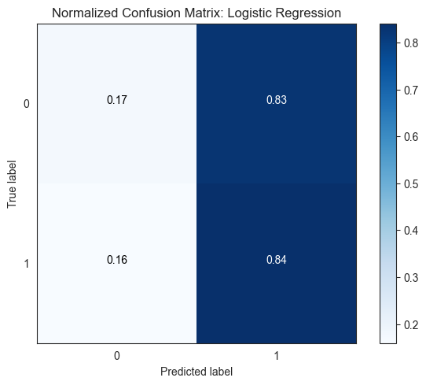

```python
model = LogisticRegression(C=0.8,
                           random_state=0,
                           solver='lbfgs')
model.fit(x_train_smote, y_train_smote)
y_predict = model.predict(x_test)

print('Accuracy Score: {:.5}'.format(accuracy_score(y_test, y_predict)))
print('Precision Score: {:.5}'.format(precision_score(y_test, y_predict)))
print('Recall Score: {:.5}'.format(recall_score(y_test, y_predict)))
print('F1 Score: {:.5}'.format(f1_score(y_test, y_predict)))

print(pd.DataFrame(confusion_matrix(y_test,y_predict)))

sns.set_style('white')
class_names = ['0','1']
plot_confusion_matrix(confusion_matrix(y_test,y_predict),
                      classes= class_names, normalize = True,
                      title='Normalized Confusion Matrix: Logistic Regression')
```

##### Decision Tree

```
Accuracy Score: 0.58681
Precision Score: 0.91619
Recall Score: 0.58449
F1 Score: 0.71368
      0     1
0   674   442
1  3435  4832
[[0.60394265 0.39605735]
 [0.41550744 0.58449256]]
```

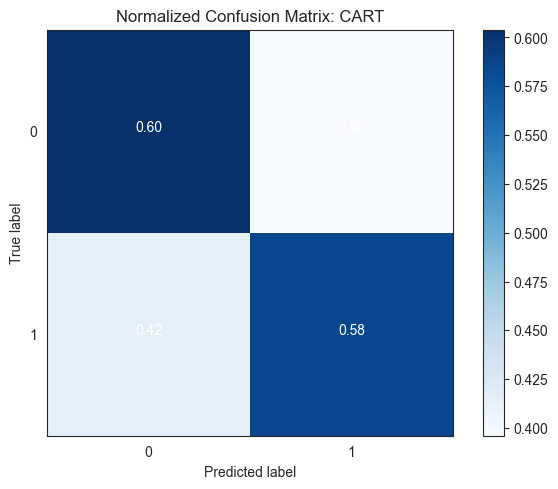

```python
model = DecisionTreeClassifier(max_depth=12,
                               min_samples_split=8,
                               random_state=1024)
model.fit(x_train_smote, y_train_smote)
y_predict = model.predict(x_test)

print('Accuracy Score: {:.5}'.format(accuracy_score(y_test, y_predict)))
print('Precision Score: {:.5}'.format(precision_score(y_test, y_predict)))
print('Recall Score: {:.5}'.format(recall_score(y_test, y_predict)))
print('F1 Score: {:.5}'.format(f1_score(y_test, y_predict)))

print(pd.DataFrame(confusion_matrix(y_test,y_predict)))

plot_confusion_matrix(confusion_matrix(y_test,y_predict),
                      classes=class_names, normalize = True,
                      title='Normalized Confusion Matrix: CART')
```

##### Random Forest

```
Accuracy Score: 0.70564
Precision Score: 0.90484
Recall Score: 0.74416
F1 Score: 0.81667
      0     1
0   469   647
1  2115  6152
[[0.4202509  0.5797491 ]
 [0.25583646 0.74416354]]
```

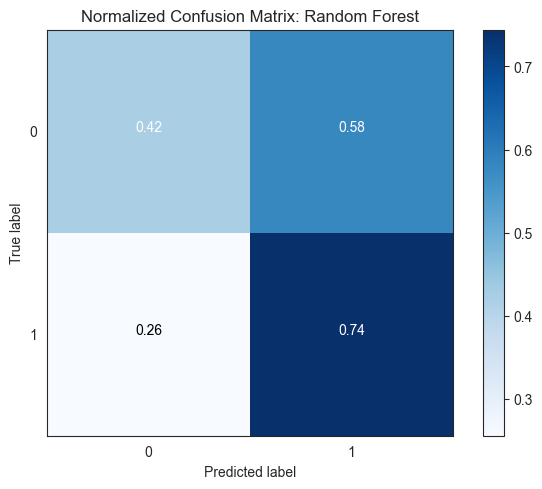

```python
model = RandomForestClassifier(n_estimators=250,
                              max_depth=12,
                              min_samples_leaf=16
                              )
model.fit(x_train_smote, y_train_smote)
y_predict = model.predict(x_test)

print('Accuracy Score: {:.5}'.format(accuracy_score(y_test, y_predict)))
print('Precision Score: {:.5}'.format(precision_score(y_test, y_predict)))
print('Recall Score: {:.5}'.format(recall_score(y_test, y_predict)))
print('F1 Score: {:.5}'.format(f1_score(y_test, y_predict)))

print(pd.DataFrame(confusion_matrix(y_test,y_predict)))

plot_confusion_matrix(confusion_matrix(y_test,y_predict),
                      classes=class_names, normalize = True,
                      title='Normalized Confusion Matrix: Random Forest')
```

### Results

$$accuracy = {{{true positives}+{true negatives}} \over {{true positives}+{true negatives}+{false positives}+{false negatives}}}$$

$$precision = {{true positives} \over {{true positives}+{false positives}}}$$
$$recall = {{true positives} \over {{true positives}+{false negatives}}}$$
$$F1 = {2*{{{precision}*{recall}} \over {{precision}+{recall}}}}$$

To simplify, we compare the Accuracy scores and F1 scores between our models.

Here we see that Logistic Regression Classifier performs well with the accuracy of 76.12% and F1 of 86.11%.  
These results should be able to be improved further with better Feature Engineering & Hyperparameter Tuning.